# GIS Portfolio

Ethan Gibson

## Canopy Cover Analysis

**Tools:** ArcGIS

**Summary:** To quantify and map canopy coverage in the Waiheke Local board.

**Findings:** Identified spatial distribution and patterns of tree canopy cover across the Waiheke Local Board Area.

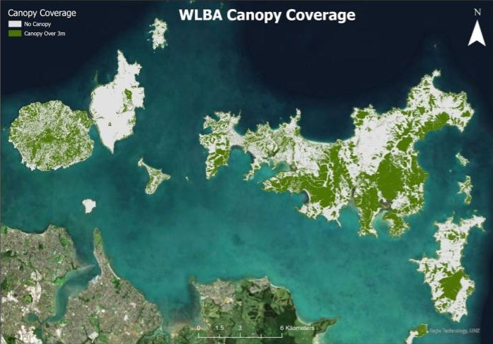

*Figure 1: Canopy Coverage of the Waiheke Local Board.*

## Participatory Mapping Work in Auckland

**Tools:** OpenStreetMap and QGIS.

**Summary:** Investigated the accuracy of OpenStreetMap data and mapped public bins in Auckland parks to assess effectiveness of council waste strategy.

**Findings:** Identified patterns of bin distribution related to population density and park use.

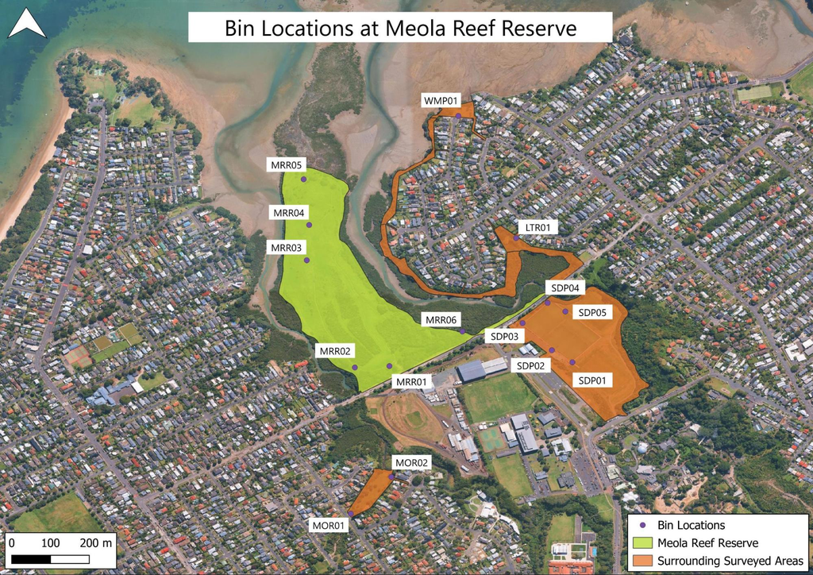

*Figure 2: Bin locations at Meola Reef Reserve and surrounding parks.*

## Life Satisfaction Analysis Over Auckland

**Tools:** Python (Google Colab: GeoPandas, Pandas, Matplotlib), QGIS.

**Summary:** Explored spatial patterns of life satisfaction scores across Auckland, focusing on age demographics and a deprivation index.

**Findings:** Areas with higher deprivation showed consistently lower life satisfaction.

*Table 1:* Life Satisfaction Scores Across Ages

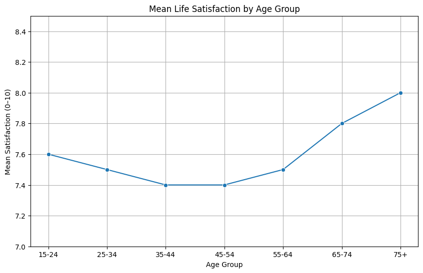

*Table 2:* Deprivation Classifications and Average Satisfaction Scores

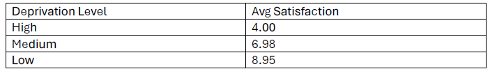

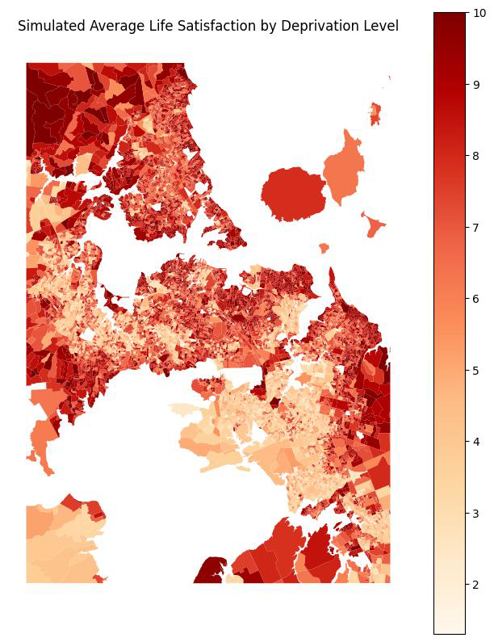

*Figure 3: Choropleth map of life satisfaction across Auckland. High life satisfaction scores = 10. Lower life satisfaction scores = 0*

## Kapoaiaia Stream, Taranaki: Riparian Analysis

**Tools:** Google Earth Engine, Sentinel-2 NDVI, LINZ Aerial Imagery, QGIS.

**Summary:** Prioritized areas for riparian restoration using NDVI change analysis and buffer zoning. Temporal change of riparian zone to show progress in the local restoration initiatives. Informing the local communities and directing their efforts.

**Findings:** Degraded riparian zones identified. Data shared with community groups for restoration planning. Growth in areas which have had focused planting initiatives Investigating priority areas for local restorations projects. To help inform the local communities and direct their efforts.

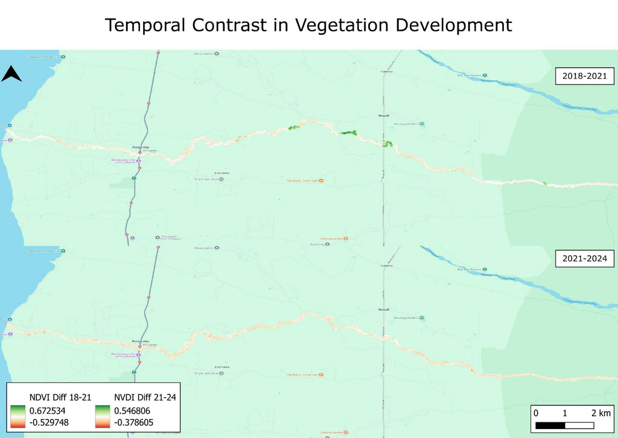

*Figure 4: Temporal NDVI change along the Kapoaiaia Stream, Taranaki (2018, 2021, and 2024).*

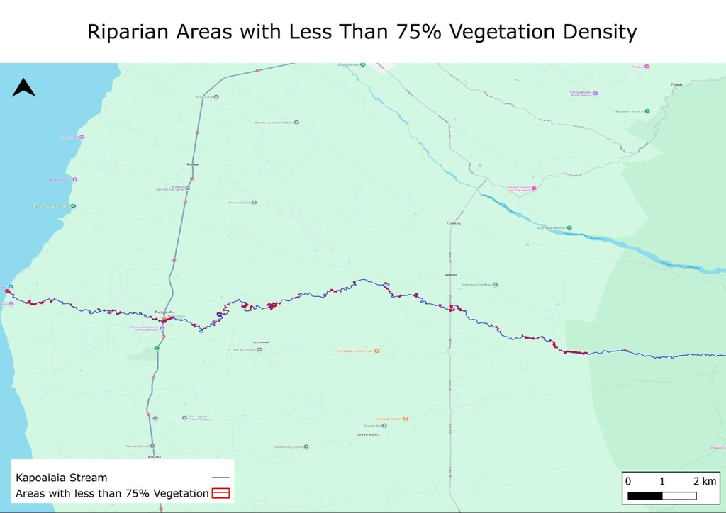

*Figure 5: Priority areas along the Kapoaiaia Stream riparian zone.*

## Toshka Lakes Region: Lake Reassertion

**Tools:** Google Earth Engine, Sentinel-2 Supervised & Unsupervised Classification.

**Summary:** Mapped and compared lake extent and vegetation development between 2015 and 2024 to evaluate hydrological changes in Egypt’s Toshka Lakes region.

**Findings:** Detected significant lake expansion linked to regional water management and flooding events. As well as an increase in agricultural sites.

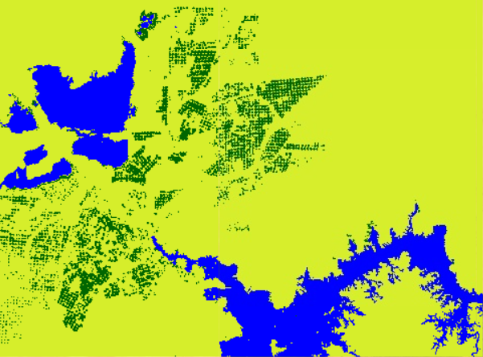

*Figure 6: Classification map highlighting water (blue), vegetation (green), and ground (yellow) classes.*

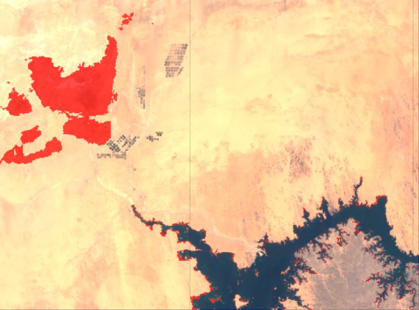

*Figure 7: Water extent change. Red areas indicated lake development between 2015 to 2024.*

## Cover Classification: Auckland

**Summary:** Provided baseline data for urban expansion monitoring.

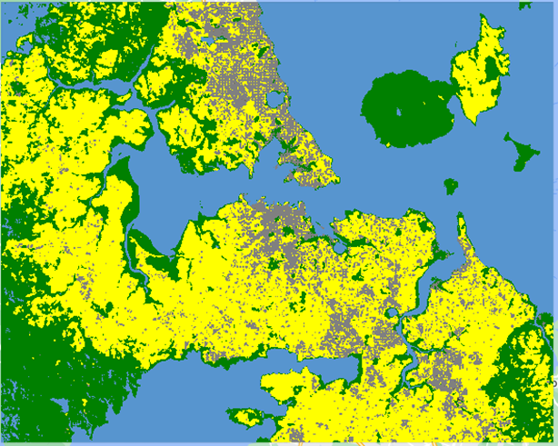

*Figure 8: Classification of Auckland (2024) with urban (grey), forest (green), rural (yellow), and water (blue) classes.*

## Accessibility Analysis of Seattle

**Tools:** Google Colab, Python, Folium.

**Summary:** Assessed accessibility of Seattle’s Airbnb locations for tourists without private vehicles.

**Findings:** Central districts have high accessibility, while limited accessibility in peripheral districts.

[figure not shown]

*Figure 9: Percentage of Airbnb locations near bus stops across the central city area. Darker areas indicate higher percentage of Airbnb locations with nearby bus stops. Lighter with lower percentage.*

## Fire Detection and Burn Area Comparison

**Tools:** Google Earth Engine, GEOS 16/17, MODIS.

**Summary:** Compared fire detection capabilities of GEOS and MODIS sensors to improve burn area mapping accuracy over Los Angeles.

**Findings:** GEOS captured fires in near real-time. MODIS provided higher spatial accuracy.

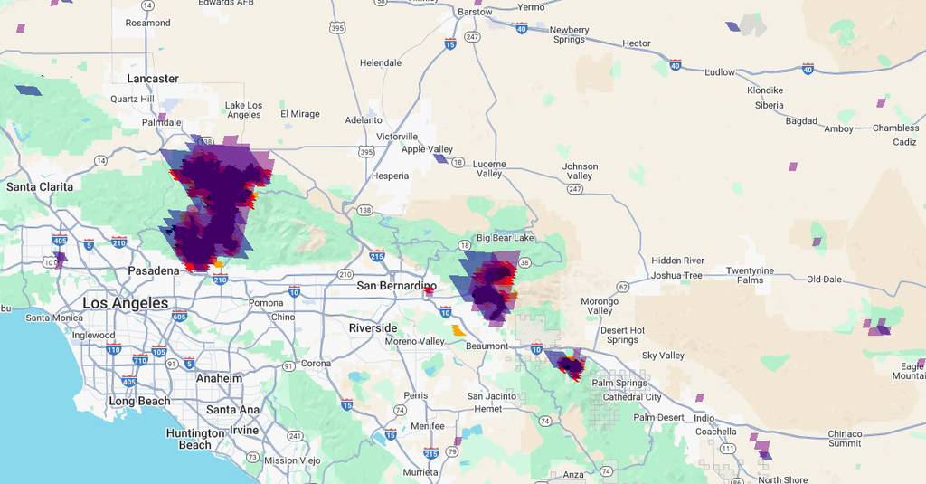

## Geomorphology and Landslide Analysis at Golden Bay

**Tools:** Google Earth Pro, ArcGIS Pro.

**Summary:** Mapped geomorphic features and landslide prone areas to evaluate terrain features and erosion potential.

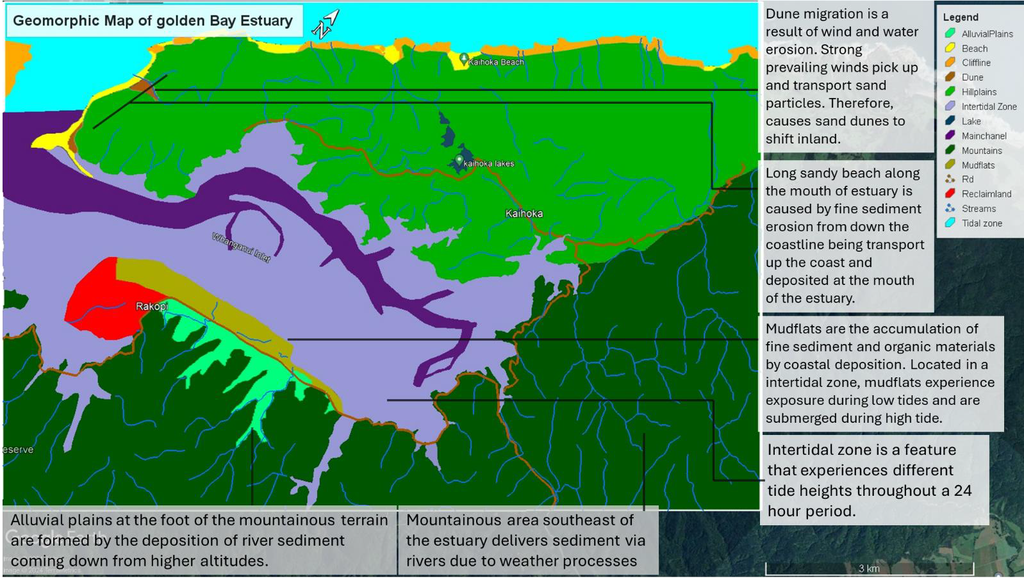

*Figure 11: Golden Bay Estuary geomorphic map.*

[figure not shown]

*Figure 12: Golden Bay catchment geomorphic map.*

## ESRI Suite Programs Used

### ArcGIS Pro

- Have used ArcGIS Pro for spatial analysis and data visualization.
- Conducted data preparation, spatial joins, and thematic mapping to explore spatial relationships and patterns within datasets.
- Created map layouts and visual outputs to support analytical interpretation.
- Published processed layers and analysis results directly to ArcGIS Online for web-based use.

### ArcGIS Online (AGOL)

- Configured interactive web maps using published ArcGIS Pro layers.
- Applied custom symbology, filtering, and pop-up configurations to enhance usability.
- Used queries and attribute filters to create data-driven insights within AGOL maps.

### ArcGIS Dashboard

- Designed an interactive dashboard visualizing vehicle crash locations in Dunedin.
- Integrated live query tools, charts, and interactive filters for dynamic spatial and statistical exploration.
- Connected dashboard components to AGOL data for real-time updates and user interactivity.